# A better answer to the Denny’s question

Wrangling spatial data

Mob 1

### Packages

In this assignment we will use the **tidyverse** and **dsbox** packages.

```r
library(tidyverse)
library(dsbox)
```

## The data

Here we are loading the data frames, as well as looking at the dimensions of a few of them

```r
states <- read_csv("U:/data Science 241/states.csv")
dn=dennys
lq =laquinta
 nrow(dennys)
```

```
[1] 1643
```

```r
 nrow(laquinta)
```

```
[1] 895
```

# Going Through the Steps

Step 1: Get all of lab 5 working, to include creating a function that takes a “state” as input and produces the output dataframe of distinces.

Here we are loading in the haversine function for later use

```r
haversine <- function(long1, lat1, long2, lat2, round = 3) {
  # convert to radians
  long1 = long1 * pi / 180
  lat1  = lat1  * pi / 180
  long2 = long2 * pi / 180
  lat2  = lat2  * pi / 180

  R = 6371 # Earth mean radius in km

  a = sin((lat2 - lat1)/2)^2 + cos(lat1) * cos(lat2) * sin((long2 - long1)/2)^2
  d = R * 2 * asin(sqrt(a))

  return( round(d,round) ) # distance in km
}
```

Here is the function from lab 05. This function took a state as an input, and output a data frame that listed every Denny’s location in a state, and listed the distance to the nearest LaQuinta from that Denny’s.

```r
map_mindist <- function(which_state) {
#step i
x = which_state

dn_x <- dennys %>%
filter(state == x)



lq_x <- laquinta %>%
filter(state == x)

dn_lq_x <- full_join(dn_x, lq_x, by = "state") %>%
mutate(distance = haversine(longitude.x, latitude.x, longitude.y, latitude.y, round = 1))

dn_lq_x_mindist <- dn_lq_x %>%
group_by(address.x) %>%
summarise(closest = min(distance))

}
```

step 2: Modify (probably already done in class) so that … given a state, if creates a dataframe that for each la quinta, it includes distance to nearest dennys.

This function flipped what was done in the map_mindist function from step 1. This function took a state as an input, and output a data frame that listed every LaQuinta’s location in a state, and listed the distance to the nearest Denny’s from that LaQuinta’s.

```r
step2_mindist <- function(which_state) {
#step i
x = which_state

dn_x <- dennys %>%
filter(state == x)


lq_x <- laquinta %>%
filter(state == x)

lq_dn_x <- full_join(lq_x, dn_x, by = "state") %>%
mutate(distance = haversine(longitude.x, latitude.x, longitude.y, latitude.y, round = 1))

lq_dn_x_mindist <- lq_dn_x %>%
group_by(address.x) %>%
summarise(closest = min(distance)) %>%
mutate(state = x)

}
```

The function also created a new variable for each data frame it outputted that listed which state was the input.

The following chunk was used for testing purposes only and can be disregarded.

```r
lq_dn_tx_mindist <- step2_mindist("TX")
# View(lq_dn_tx_mindist)

# dn_tx <- dennys %>%
# filter(state == "TX")
# nrow(dn_tx)num_den = nrow(dn_x)
```

Step 3: Grab the dataset (available in moodle in “week of 28 Sep” ) for the 10000 US restaurants.

In this chunk, we are creating a data frame of all the other restaurants.

```r
fas_foo <- read_csv("U:/data Science 241/FastFoodRestaurants.csv")
fast_food <- fas_foo %>%
  rename(
    state = province
    )

# View(fast_food)

# for some absolutely incomprehensible reason you have to reload the files window for this to run.
```

Step 4: Create a function that takes a “state” as input and produces a dataframe, where there is one observation per “la quinta” and it lists distance to nearest “Restaurant”.

This function creates a data frame with the least distance from every LaQuinta in a state to a random sample of other restaurants. This random sample is of the same size as the number of Denny’s in that state

```r
step4_mindist <- function(which_state) {
#step i
x = which_state

lq_x <- laquinta %>%
filter(state == x)

fast_food_x <- fast_food %>%
  filter(state == x) %>%
  sample_n(nrow(dennys %>% filter(state==x)))

lq_rest_x <- full_join(lq_x, fast_food_x, by = "state") %>%
mutate(distance = haversine(longitude.x, latitude.x, longitude.y, latitude.y, round = 1))

lq_rest_x_mindist <- lq_rest_x %>%
group_by(address.x) %>%
summarise(closest = min(distance)) %>%
mutate(state = x)

}
```

calling the function above to create closest distances to LaQuinta’s amongst a random sampling of restaurants.

The following code chunk creates a data frame with the least distance from every LaQuinta in Texas to a random sample of resaurants

```r
lq_rest_tx_mindist4 <- step4_mindist("TX")
# View(lq_dn_tx_mindist)
```

Step 5: Do some comparative analysis on several states of interest.  
Are “denny’s” any closer than the “other” restaurants?

Summary statistics for other restaurants closest distances

```r
summary(lq_rest_tx_mindist4$closest)
```

```
   Min. 1st Qu.  Median    Mean 3rd Qu.    Max.
    0.2     3.4     7.1    22.1    25.5   213.4
```

Summary statistics for dennys closest distances

```r
summary(lq_dn_tx_mindist$closest)
```

```
   Min. 1st Qu.  Median    Mean 3rd Qu.    Max.
   0.00    1.10    5.00   15.99   16.50  185.20
```

This chunk generates a visual of overlapping histograms of closest distances corresponding to Denny’s and the other randomly sampled restaurants.

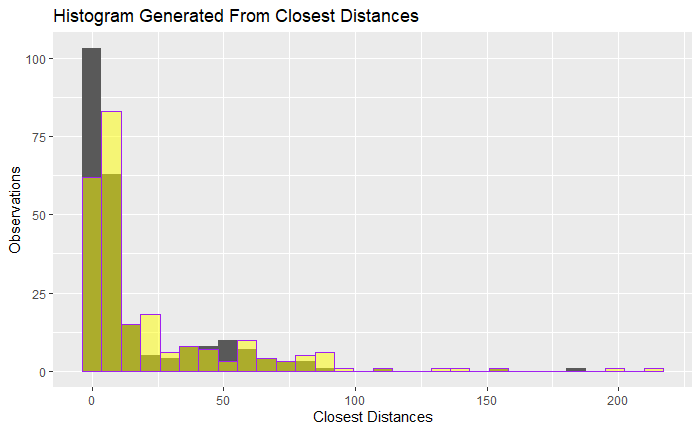

```r
#lq_dn_tx_mindist %>%
ggplot(lq_dn_tx_mindist,aes(x = closest)) +
  #histogram of original data
  geom_histogram() +
    geom_histogram(data = lq_rest_tx_mindist4,
                   colour = "purple",
                   fill = "yellow", alpha = 0.5) +
  labs(
    title = "Histogram Generated From Closest Distances",
    x = "Closest Distances",
    y = "Observations"
  )
```

Normal distributions are generated from the data shown in the histograms shown above and displayed for comparison.

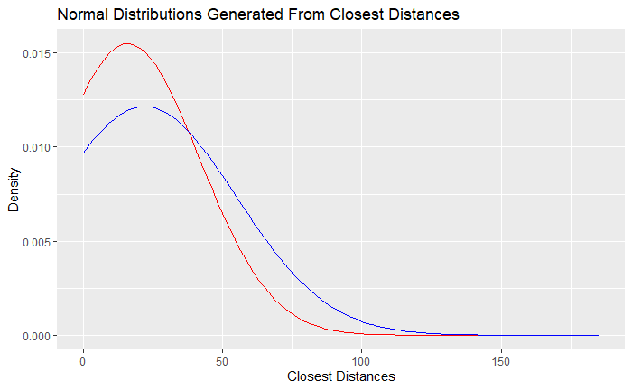

```r
#lq_dn_tx_mindist %>%
ggplot(lq_dn_tx_mindist,aes(x = closest)) +
  #histogram of original data

stat_function(fun = dnorm, args = list(mean = mean(lq_dn_tx_mindist$closest), sd = sd(lq_dn_tx_mindist$closest)),color="red") +

stat_function(fun = dnorm, args = list(mean = mean(lq_rest_tx_mindist4$closest), sd = sd(lq_rest_tx_mindist4$closest)),color="blue") +
  labs(
    title = "Normal Distributions Generated From Closest Distances",
    x = "Closest Distances",
    y = "Density"
  )
```

The dennys distribution has a higher density of smaller distances whereas the other restaurants have a higher density of higher distances.

Since the other restaurants are randomly sampled to match the number of dennys in a certain state, the following analysis performs n number of random samplings and averages out the samplings for another comparison.

```r
n_samples <- 500
averaged_lq_rest_tx_mindist <- step4_mindist("TX") %>% select(closest)

for (i in 1:n_samples){
  averaged_lq_rest_tx_mindist = cbind(averaged_lq_rest_tx_mindist, step4_mindist("TX") %>% select(closest))

}
# averaging all closest distances randomly sampled
#averaged_lq_rest_tx_mindist <- rowMeans(averaged_lq_rest_tx_mindist)
```

next step in the process

```r
averaged_lq_rest_tx_mindist$average = rowMeans(averaged_lq_rest_tx_mindist)
averaged_lq_rest_tx_mindist <- averaged_lq_rest_tx_mindist %>% select(average)
```

this chunk produces visualization

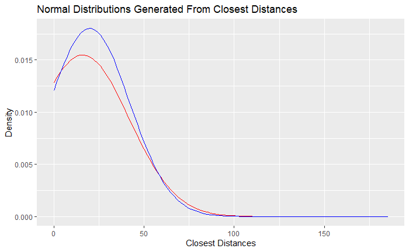

```r
#lq_dn_tx_mindist %>%
ggplot(lq_dn_tx_mindist,aes(x = closest)) +
  #histogram of original data

stat_function(fun = dnorm, args = list(mean = mean(lq_dn_tx_mindist$closest), sd = sd(lq_dn_tx_mindist$closest)),color="red") +

stat_function(fun = dnorm, args = list(mean = mean(averaged_lq_rest_tx_mindist$average), sd = sd(averaged_lq_rest_tx_mindist$average)),color="blue") +
  labs(
    title = "Normal Distributions Generated From Closest Distances",
    x = "Closest Distances",
    y = "Density"
  )
```

Comparison for New York

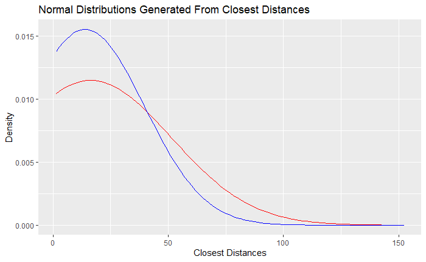

```r
#lq_dn_tx_mindist %>%
ggplot(step2_mindist("NY"),aes(x = closest)) +
  #histogram of original data

stat_function(fun = dnorm, args = list(mean = mean(step2_mindist("NY")$closest), sd = sd(step2_mindist("NY")$closest)),color="red") +

stat_function(fun = dnorm, args = list(mean = mean(step4_mindist("NY")$closest), sd = sd(step4_mindist("NY")$closest)),color="blue") +
  labs(
    title = "Normal Distributions Generated From Closest Distances",
    x = "Closest Distances",
    y = "Density"
  )
```

The comparison can be made with any other state using the above code chunk, as long as you with the “NY”s to any other state abbreviation.